# BST270: Individual Project

Liz Graff

## Introduction

In this Rmarkdown file I attempt to reproduce the figures that appear in the article [“How Americans Like Their Steak”](https://fivethirtyeight.com/features/how-americans-like-their-steak/) written by Walt Hickey published on May 16, 2014. The author hypothesized that people who take risky behaviors may have a tendency to eat their steaks rare (and therefore risk foodborne ilness). His team collected survey data asking respondents about their participation in risky behaviors e.g., skydiving, speeding, smoking, lottery, in addition to their preferred steak doneness (spoiler: he found no obvious correlations).

## Package and Data loading

Load the necessary packages and set the working directory, i.e. , the location where the repository is housed. Be sure to change the path of the working directory to your own local directory i.e., `setwd("/path/to/your/local/directory/here")`

```r
# load all packages used to wrangle data and generate plots
library(knitr)
library(tidyverse)
library(data.table)

# set working directory -- Note: change this path to wherever the repository lives
# on your local machine
setwd("/Users/ecyoo/Desktop/BST270_ReprodDS/2024_bst270_individual_project")
```

## Read data

```r
if (file.exists("./data/steak-survey/steak-risk-survey.csv")) {
  survey_data <- fread("./data/steak-survey/steak-risk-survey.csv")
} else {
  fwrite(survey_data, "./data/steak-survey/steak-risk-survey.csv")
}
```

## Data preprocessing

```r
# get the number of rows and columns in the survey dataset
dim(survey_data)
```

```
## [1] 551  15
```

```r
# get column names of the data -- they were not included in the dataset README
colnames(survey_data)
```

```
##  [1] "RespondentID"
##  [2] "Consider the following hypothetical situations: <br>In Lottery A, you have a 50% chance of success, with a payout of $100. <br>In Lottery B, you have a 90% chance of success, with a payout of $20. <br><br>Assuming you have $10 to bet, would you play Lottery A or Lottery B?"
##  [3] "Do you ever smoke cigarettes?"
##  [4] "Do you ever drink alcohol?"
##  [5] "Do you ever gamble?"
##  [6] "Have you ever been skydiving?"
##  [7] "Do you ever drive above the speed limit?"
##  [8] "Have you ever cheated on your significant other?"
##  [9] "Do you eat steak?"
## [10] "How do you like your steak prepared?"
## [11] "Gender"
## [12] "Age"
## [13] "Household Income"
## [14] "Education"
## [15] "Location (Census Region)"
```

```r
# drop rows containing NAs
survey_data <- drop_na(survey_data)
# get the number of rows and columns in the survey dataset after dropping nuisance rows
dim(survey_data)
```

```
## [1] 550  15
```

We see that the survey data is 551 rows by 15 columns, and the “Response” entry takes up a row. The article states that there were 550 respondents, which is the number of rows we get after dropping the row with NAs.

We are interested in the following columns: (1) column 2, the respondent”s preference for lottery A (the riskier lottery) vs. lottery B (the safer lottery) (2) column 9, whether or not they eat steak (3) column 10, how they like their steak prepared

We”ll subset the data to contain these three columns (in addition to respondent IDs) and for brevity and machine-readability, we will rename the columns of interest to: (1) “lottery” (2) “eats_steak” (3) “steak_doneness”.

We are only interested in those that eat steak, so we will filter accordingly.

```r
# subset data
survey_data_sub <- survey_data[,c(1,2,9,10)]

# rename columns 2, 9, 10
colnames(survey_data_sub)[2] <- "lottery"
colnames(survey_data_sub)[3] <- "eats_steak"
colnames(survey_data_sub)[4] <- "steak_doneness"

# subset only respondents that eat steak
steak_data <- survey_data_sub[eats_steak=="Yes", ]
```

## Reproducing the bar chart

Since the table and the bar chart are in terms of percentages and not raw values, we calculate the percentages of each steak doneness category, overall and stratified by lottery type.

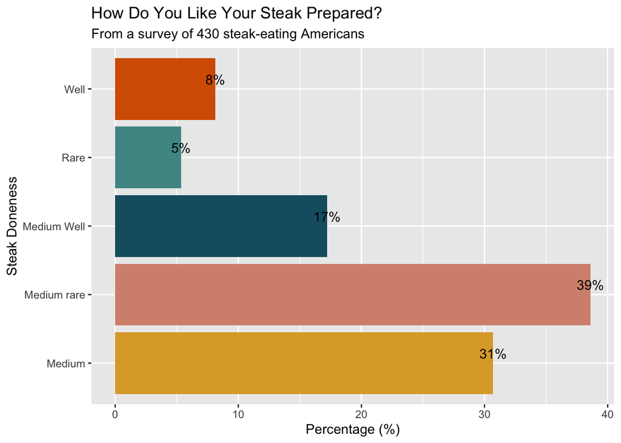

```r
# calculate population-wide percentages
overall_percentages <- steak_data %>%
  count(steak_doneness) %>%
  mutate(percentage = n / sum(n) * 100) %>%
  ungroup()

# generate bar plot
ggplot(overall_percentages, aes(x = steak_doneness, y = percentage)) +
    geom_col(fill = c("#dda832", "#165e70", "#d5927c", "#4f9694", "#d55e00")) +
    geom_text(aes(label = sprintf("%.0f%%", percentage)), vjust = -0.5) +
    ggtitle("How Do You Like Your Steak Prepared?", subtitle="From a survey of 430 steak-eating Americans") +
    xlab("Steak Doneness") +
    ylab("Percentage (%)") +
    coord_flip() # the bar chart in the article is horizontal
```

## Reproducing the table

Now we calculate percentages preferred steak doneness for each preferred lottery type. Notice that there some rows that have an empty string value for lottery, so we will disregard those rows.

```r
# drop rows containing empty strings for lottery
steak_data <- steak_data[lottery != ""]

# calculate percentages of steak doneness, stratified by lottery type
stratified_percentages <- steak_data %>%
    # group by both columns
    group_by(lottery, steak_doneness) %>%
    # count occurrences
    summarise(count = n()) %>%
    # calculate percentage within each lottery type
    mutate(percentage = count / sum(count) * 100)  %>%
    ungroup()
# reshape the strafied percentages in the format of the table
stratified_table <- stratified_percentages %>%
  pivot_wider(
    names_from = lottery,
    values_from = percentage,
    values_fill = list(percentage = 0)
  )

# aggregate multiple rows for same level of steak doneness
stratified_table <- stratified_table %>%
  group_by(steak_doneness) %>%
  summarise(
    Count = sum(count, na.rm = TRUE),
    `Lottery A` = sum(`Lottery A`, na.rm = TRUE),
    `Lottery B` = sum(`Lottery B`, na.rm = TRUE)
  )

# format e.g. rename columns, remove count column to match the style of table in the article
formatted_table <- stratified_table %>%
  select(-Count) %>%
  rename(
    `Steak preference` = `steak_doneness`,
    `Respondents who chose the riskier lottery` = `Lottery A`,
    `Respondents who chose the safer lottery` = `Lottery B`
  ) %>%
  mutate(
    `Respondents who chose the riskier lottery` = sprintf("%.2f%%", `Respondents who chose the riskier lottery`),
    `Respondents who chose the safer lottery` = sprintf("%.2f%%", `Respondents who chose the safer lottery`)
  )
# display formatted table
kable(formatted_table)
```

| Steak preference | Respondents who chose the riskier lottery | Respondents who chose the safer lottery |
| --- | --- | --- |
| Medium | 36.10% | 25.79% |
| Medium Well | 16.10% | 18.10% |
| Medium rare | 35.61% | 41.18% |
| Rare | 4.88% | 5.88% |
| Well | 7.32% | 9.05% |